# U.S. Incarceration Trends

Sukhman Dhillon

2022-11-21

## Abstract

With this dataset, the main question I plan on addressing is what are the trends that exist with incarceration rates in the U.S. from 1970 to 2018? From those trends, I am going to investigate if any reveal inequalities such as if certain races are being incarcerated more than others and if certain states or regions contribute most to that.

## Introduction

This dataset describes many different aspects of people who have been incarcerated in the United States from 1970 – 2018 including race, gender, regions, and many more. Social issues such as whether some populations of people that belong to certain groups are being disproportionately incarcerated are in this dataset. This is a problem because it would show that there are issues with the justice system, such as systemic racism where Black populations are being incarcerated most.

Direct stakeholders that are impacted by research into this dataset are people like public officials who are interested in learning whether systemic racism is taking place and what places specifically are contributing most to it. With this information, these stakeholders can improve policies regarding incarceration so that unfair trends are removed. Indirect stakeholders that are impacted by research into this dataset could be racial groups that are being disproportionately discriminated in the justice system. This is because the change in policies that direct stakeholders can implement will affect the current trends so that these groups are no longer unfairly treated.

Central values that I need to engage is trust and community. This is because if incarceration trends between certain racial groups are unfair, trust in the justice system will decrease and create animosity between citizens and the laws. Community is a central value in increasing trust and thus decrease crime, so it is necessary for incarceration trends to show that certain populations aren’t being targeted more over others.

Questions I answer in my report include:

- How has the U.S. prison population changed from 1970 to 2018?
- How has the U.S. prison population changed between certain states from 1970 to 2018?
- How do jailed Black population and total jailed population correlate with each other by region in 2018?
- How does the proportion of jailed Black population compare by state in 2018?

## Data Summary

I looked into variables about the average population of Black people in jail, the state in which the highest average number of Black people being jailed is, as well as the type of location that incarcerates the highest average number of people. I looked at all of these variables across the U.S. and specifically in 2018 to get sense of the most recent data. I learned that the average number of incarcerations daily of Black people in the U.S. in 2018 was 84. This value tells us what the rate is with the most recent data available which we can use to compare it to previous years and find that this number is increasing. This can show trends of inequality because within this number, we can see if specific populations of people are making up that total more than others. The location with the highest average incarcerations daily of Black people in 2018 was the District of Columbia. This value tells us that a specific state has actually not had the most incarcerations but rather the national capital which is interesting. It can tell us that systemic racism arose there, where laws are created. Because the white house is also there, it isn’t surprising that a lot of security and incarcerations take place. Finally, the Urban-Rural Classification with the largest average total population in jail daily in 2018 in the U.S. is urban. This helps us makes sense of the idea that Washington D.C. had the highest average incarceration rates of Black people because it is a place that has a large population with at least a million people. These values help show that there are trends between Black people being incarcerated and the location.

## Growth of the U.S. Prison Population

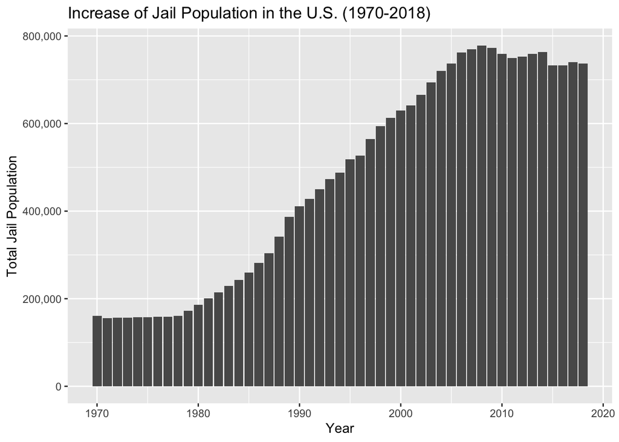

## Growth of Prison Population by State

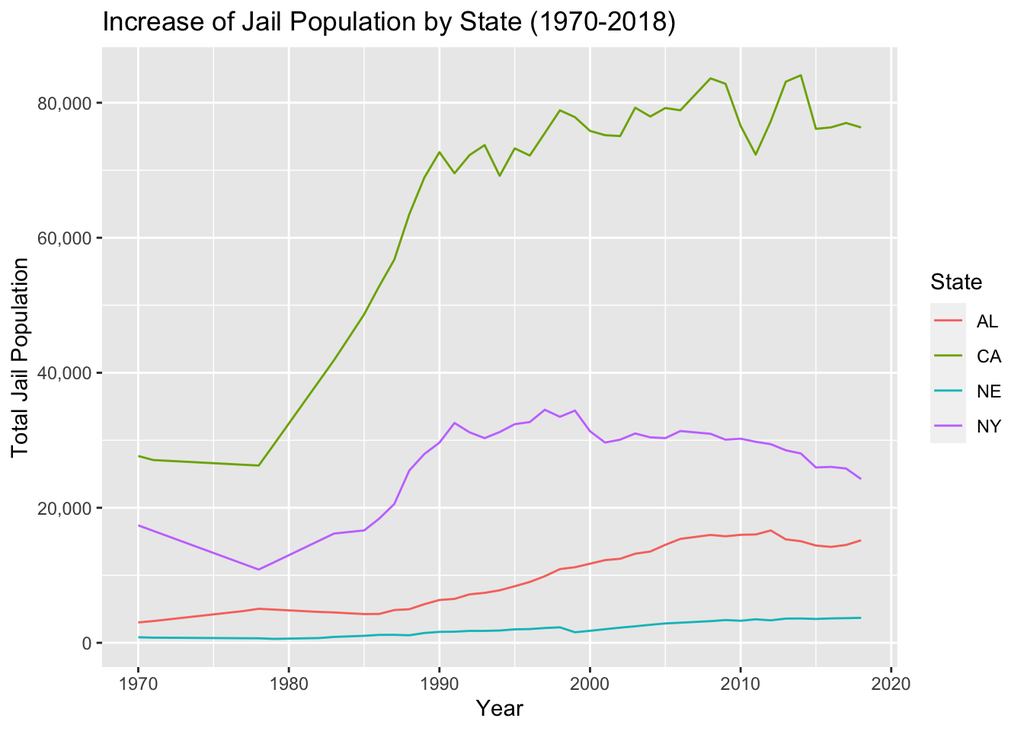

## Black vs. Total Jailed Population by Region (2018)

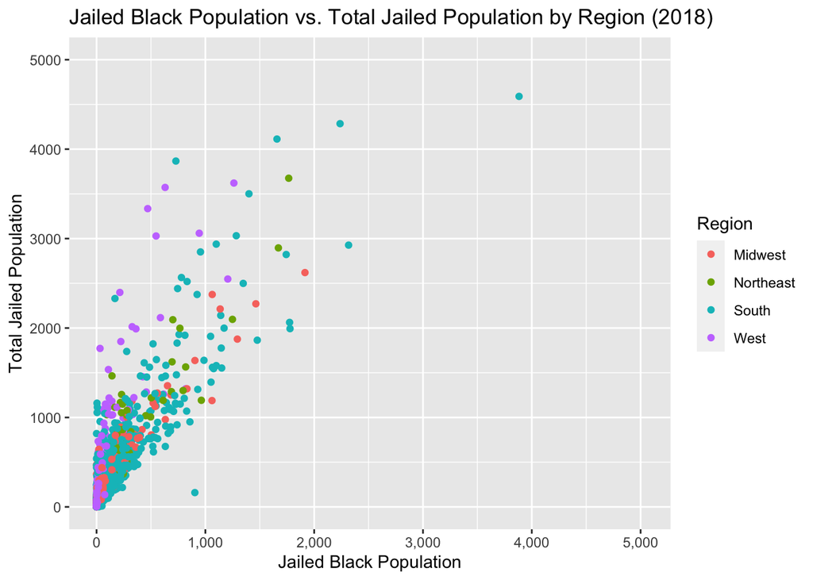

#### Caption: Graph of the Black jailed population vs. the total jailed population by region in 2018.

### Summary

The question I wanted to address was how do jailed Black population and total jailed population correlate with each other by region in 2018? In this graph, a more linear trend of points through the middle of the graph (where the slope would be around 1) would indicate that the population of Black people in jail makes up almost the total jail population in a location. According to this graph, the blue points that represents the South slightly follows this correlation between Black people in jail and the overall jail population the most. This means that compared to the other regions, the South tends to have Black people make up most of the jail population compared to other races. This indicates an inequality in incarcerations in the U.S. because the certain area one lives in the U.S. can affect whether a race is arrested at higher rates than others. In this graph, the purple points that represent the West has a much smaller population of Black people in jail that make up the total population. This shows that there’s an inequality in the amount of Black people jailed based on region.

## Proportion of Black People Jailed by State (2018)

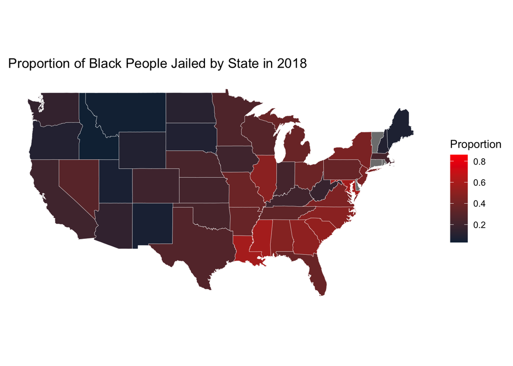

#### Caption: Map of the proportion of Black people jailed by state in 2018.

### Summary

The question I wanted to address was how does the proportion of jailed Black population compare by state in 2018? In this map, states with a brighter shade of red have a larger proportion of Black people in jail of the total jailed population in that state in 2018. According to this map, states in the South like Louisiana, Alabama, or Mississippi have the brightest shade of red or largest proportion of Black people jailed. States in the West like Oregon and California have a proportion of around 0.3 compared to the ones in the South of around 0.7. This indicates inequality because Black people that tend to live in the states in the South with a larger proportion may have a higher chance of being incarcerated compared to other states. This shows that there’s an inequality in incarcerations in the U.S. because certain states have Black people make up more of their jail population than others.